# Homework 7

Ryan Corydon and Emma Podlich

2023-03-20

Link to GIBHUB Repository: https://github.com/ryancorydon8/homework7

```r
library(dplyr)
```

```r
library(tidyr)
library(ggplot2)
```

```r
HAPPY <- readRDS("data/HAPPY.rds")
```

## Part 1 (cleaning)

1. Data cleaning: the values “IAP”, “DK” and “NA” all encode missing values. Replace all of these instances by the value NA.

```r
HAPPY[HAPPY == "IAP" | HAPPY == "DK" | HAPPY == "NA"] <- NA
```

2. Check the type of the variable and cast into the right type (factor variable for categorical variables). For age, change “89 OR OLDER” to 89 and assume the variable should be numeric.
3. Bring all levels of factors into a sensible order. For marital you could e.g. order the levels according to average age.

```r
str(HAPPY)
```

```
## 'data.frame':    62466 obs. of  11 variables:
##  $ HAPPY   : chr  "NOT TOO HAPPY" "NOT TOO HAPPY" "PRETTY HAPPY" "NOT TOO HAPPY" ...
##  $ YEAR    : int  1972 1972 1972 1972 1972 1972 1972 1972 1972 1972 ...
##  $ AGE     : chr  "23" "70" "48" "27" ...
##  $ SEX     : chr  "FEMALE" "MALE" "FEMALE" "FEMALE" ...
##  $ MARITAL : chr  "NEVER MARRIED" "MARRIED" "MARRIED" "MARRIED" ...
##  $ DEGREE  : chr  "BACHELOR" "LT HIGH SCHOOL" "HIGH SCHOOL" "BACHELOR" ...
##  $ FINRELA : chr  "AVERAGE" "ABOVE AVERAGE" "AVERAGE" "AVERAGE" ...
##  $ HEALTH  : chr  "GOOD" "FAIR" "EXCELLENT" "GOOD" ...
##  $ WTSSALL : num  0.445 0.889 0.889 0.889 0.889 ...
##  $ PARTYID : chr  "IND,NEAR DEM" "NOT STR DEMOCRAT" "INDEPENDENT" "NOT STR DEMOCRAT" ...
##  $ POLVIEWS: chr  NA NA NA NA ...
```

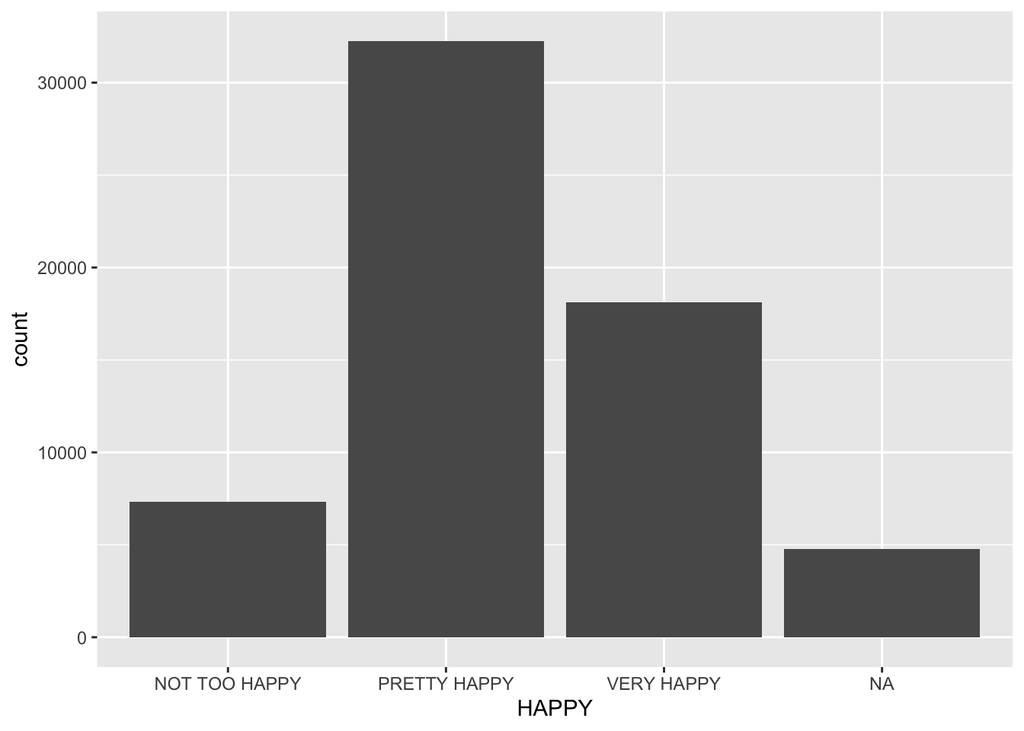

```r
HAPPY$HAPPY <- as.factor(HAPPY$HAPPY)
HAPPY %>% ggplot(aes(x = HAPPY)) + geom_bar()
```

```r
# This plot shows that order of happiness from greatest to least amount of people for this data set is in the following order: pretty happy, very happy, not too happy, and NA. Most people are pretty happy or very happy in this data set and not as many are unhappy.
```

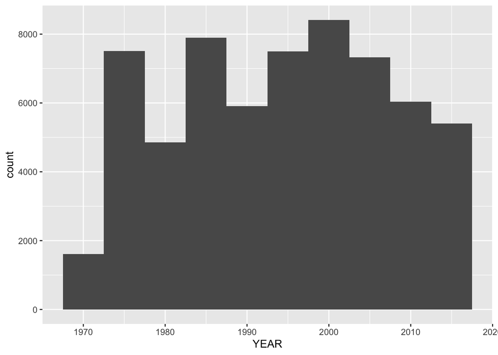

```r
HAPPY$YEAR <- as.numeric(HAPPY$YEAR)
HAPPY %>% ggplot(aes(x = YEAR)) + geom_histogram(binwidth=5)
```

```r
# This plot shows that there are good variety of years represented in this data set from 1972 to 2016. The greatest amount of data is from the late 1990s-early 2000s but there is still a lot in other years. The least amount of data is from the early 1970s.
```